# Craft Beers: An Exploratory Analysis

Like most of my flannel sporting, bearded, aging Millenial brethren, I enjoy a nice craft beer from time to time. But I am not a beer aficiando - I couldn’t tell the difference between an American Pale Lager and an American Pale Ale. Yet I still find it worthwhile to investigate some trends, from a novice’s perspective.

### Data Processing & Cleaning

First thing first, we need to process and clean the data. The data is already fairly clean, so not much needs to be done except for a simple join and some name changes.

```r
library(tidyverse)
library(stringr)
library(maps)

beers <- read_csv('beers.csv')
breweries <- read_csv('breweries.csv')

beers <- beers[ , -1]
names(beers)[4] <- 'beer_name'
names(breweries)[1:2] <- c('brewery_id', 'brewery_name')

beers <- left_join(beers, breweries, by = 'brewery_id')
```

### The Beers

There are a lot of different beer styles in this dataset: 99 to be exact. Below is a random list of 20.

```r
sample(unique(beers$style[!is.na(beers$style)]), 20)
```

```
##  [1] "Winter Warmer"
##  [2] "American Pilsner"
##  [3] "English Pale Ale"
##  [4] "Herbed / Spiced Beer"
##  [5] "English India Pale Ale (IPA)"
##  [6] "American Adjunct Lager"
##  [7] "American Strong Ale"
##  [8] "Scottish Ale"
##  [9] "Belgian Strong Dark Ale"
## [10] "Other"
## [11] "English Strong Ale"
## [12] "English Barleywine"
## [13] "American Porter"
## [14] "Shandy"
## [15] "American India Pale Lager"
## [16] "Dunkelweizen"
## [17] "Radler"
## [18] "Märzen / Oktoberfest"
## [19] "American Double / Imperial IPA"
## [20] "American Double / Imperial Pilsner"
```

So what do these different types of beers have in common, or how do they differ? We’ll take a look.

### Most Popular Beers

Below is a plot of the 15 most popular types of beers brewed. “American IPA” drawves the competition, followed by the “American Pale Ale”. Interesting to note, I never even heard of “Vegetable Beer” before, yet it’s somewhat popular.

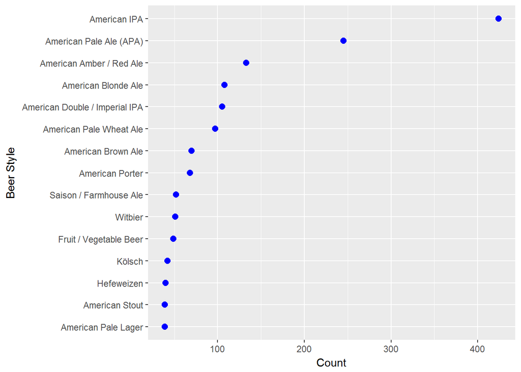

```r
beers %>%
  count(style, sort = T) %>%
  head(15) %>%
  ggplot(mapping = aes(x = reorder(style, n), y = n)) +
    geom_point(color = 'blue', size = 2.5) +
    coord_flip() +
    labs(x = 'Beer Style', y = 'Count')
```

### ABV Content

Another important aspect of beer is the **ABV**: the percentage of alcohol content. Below we see a distribution of the ABV values among our sample. Most ABV values are within the 0.05 mark, with a heavy rightward tail indicating more beers with higher alcohol content.

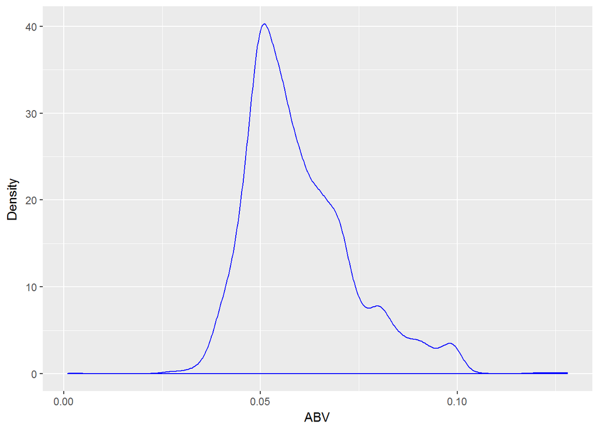

```r
ggplot(beers) +
  geom_density(mapping = aes(abv), color = 'blue') +
  labs(x = 'ABV', y = 'Density')
```

Just out of curiosity, below is a plot showing the ABV distributions for three of our most common brews (the “American IPA” has quite the kick).

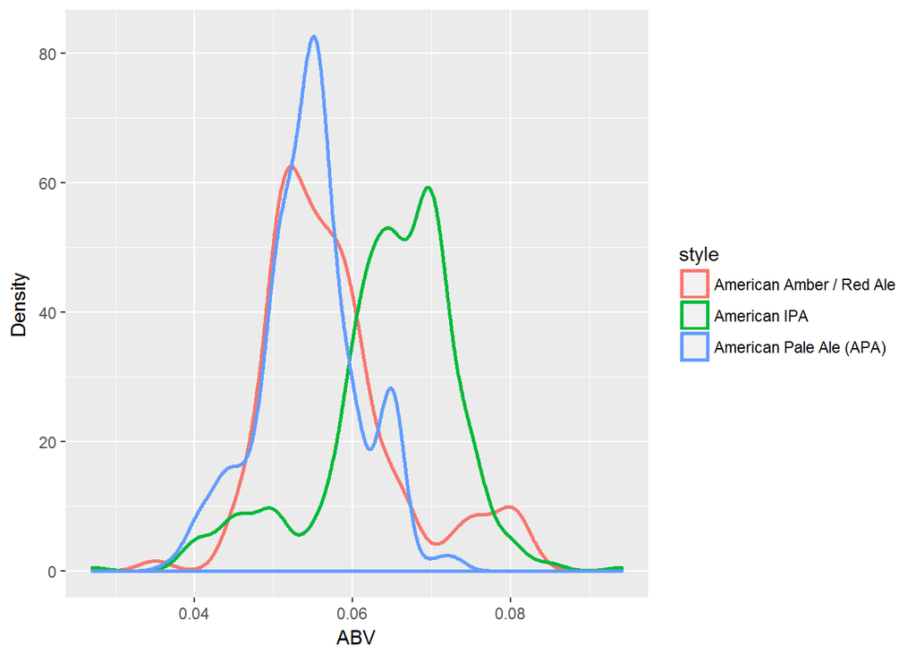

```r
styles <- c('American IPA',
            'American Pale Ale (APA)',
            'American Amber / Red Ale')

beers %>%
  filter(style %in% styles) %>%
  ggplot() +
    geom_density(mapping = aes(x = abv, color = style), size = 1) +
  labs(x = 'ABV', y = 'Density')
```

Hypothetically, let’s say I really like my alcohol with some bite. Which beer styles would satiate my palate? According to the plot below, one of the safest bets would be an imperial stout.

*Note: the plot only includes beer styles which have at least 5 selections, to account for at least **some** variability.*

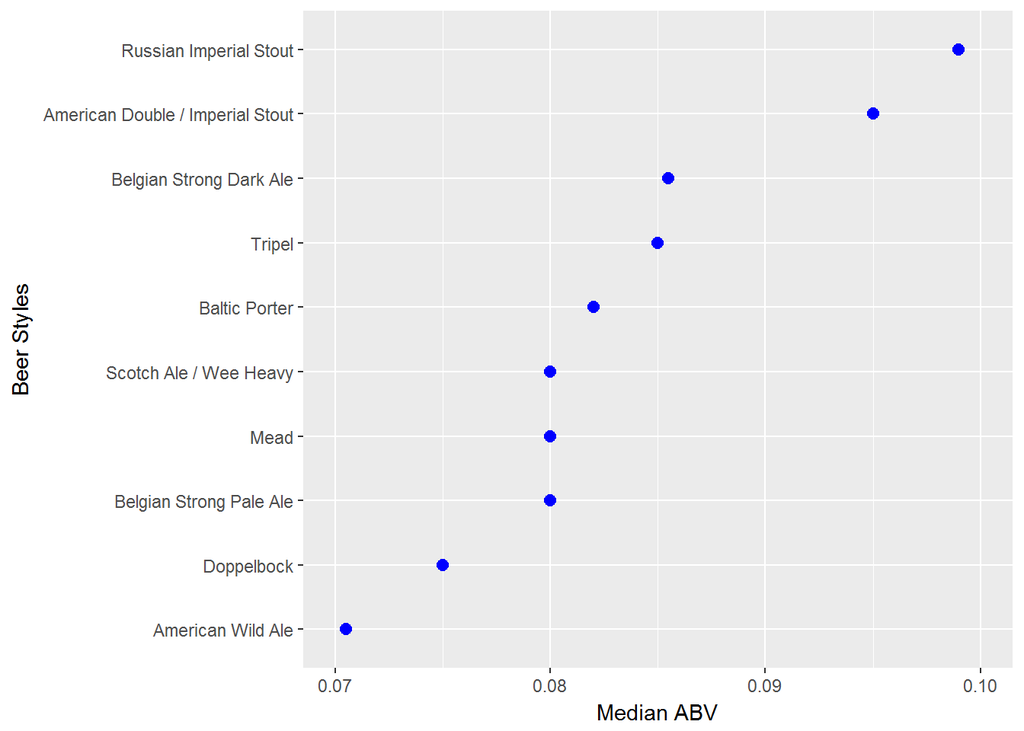

```r
beers %>%
  group_by(style) %>%
  summarise(med_abv = median(abv), n = n()) %>%
  filter(n >= 5) %>%
  arrange(desc(med_abv)) %>%
  filter(row_number() <= 10) %>%
  ggplot(mapping = aes(x = reorder(style, med_abv), y = med_abv)) +
    geom_point(size = 2.5, color = 'blue') +
  labs(x = 'Beer Styles', y = 'Median ABV') +
  ylim(.07, .10) +
  coord_flip()
```

And if I felt like traveling the states to quench my ABV thirst, then I should clearly stay away from Utah - as detailed from the map below.

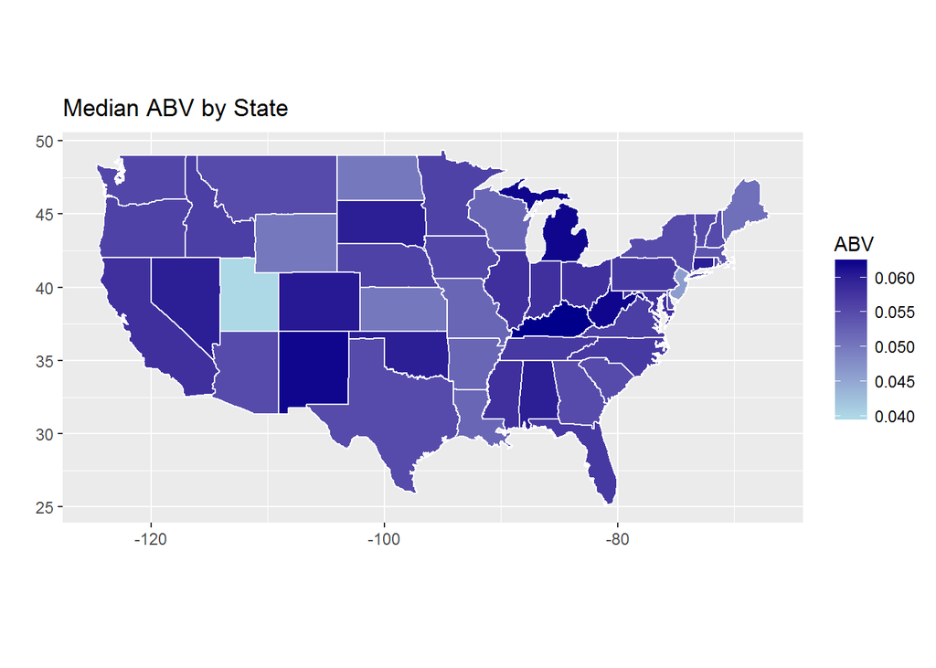

```r
states <- map_data('state')

beers %>%
  mutate(state = tolower(state.name[match(state, state.abb)])) %>%
  group_by(state) %>%
  summarise(med_abv = median(abv, na.rm = T)) %>%
  ggplot() +
    geom_map(aes(map_id = state, fill = med_abv), color = 'white', map = states) +
    expand_limits(x = states$long, y = states$lat) +
    labs(x = '', y = '', title = 'Median ABV by State') +
    scale_fill_continuous(name = 'ABV', low = 'light blue', high = 'dark blue') +
    coord_quickmap()
```

### My Personal Favorites

Like I said previously, I enjoy craft beer, but only a select few: IPAs, Stouts, Porters, and Ciders. So I thought I’d quickly take a peek at how these brews compare and contrast.

Since the beer styles vary, we’ll have to create another column to quantify my selections.

```r
favs <- beers %>%
  mutate(favorite = ifelse(str_detect(style, 'IPA'), 'IPA',
                    ifelse(str_detect(style, 'Stout'), 'Stout',
                    ifelse(str_detect(style, 'Porter'), 'Porter',
                    ifelse(str_detect(style, 'Cider'), 'Cider', 'Other'))))) %>%
  filter(favorite != 'Other')
```

Now, the table below tells me which breweries I should visit by counting the total number of my preferred beers that are brewed by each brewery.

It looks like [Brewery Vivant](http://www.breweryvivant.com/) in Michigan and [Oskar Blues Brewery](https://www.oskarblues.com/) in Colorado would be excellent choices.

```r
favs %>%
  group_by(brewery_name, state) %>%
  summarise(Total = n(),
            IPA = sum(favorite == 'IPA'),
            Stout = sum(favorite == 'Stout'),
            Porter = sum(favorite == 'Porter'),
            Cider = sum(favorite == 'Cider')) %>%
  arrange(desc(Total)) %>%
  head(10)
```

```
## Source: local data frame [10 x 7]
## Groups: brewery_name [10]
##
##                  brewery_name state Total   IPA Stout Porter Cider
##                         <chr> <chr> <int> <int> <int>  <int> <int>
## 1              Brewery Vivant    MI    17    10     6      1     0
## 2         Oskar Blues Brewery    CO    17    14     3      0     0
## 3  Cigar City Brewing Company    FL    12    10     0      2     0
## 4    Sun King Brewing Company    IN    12     8     2      2     0
## 5         Golden Road Brewing    CA     9     9     0      0     0
## 6         Sixpoint Craft Ales    NY     9     6     1      2     0
## 7         18th Street Brewery    IN     7     5     1      1     0
## 8      21st Amendment Brewery    CA     7     5     1      1     0
## 9      Great Crescent Brewery    IN     7     2     2      3     0
## 10        Ska Brewing Company    CO     7     3     4      0     0
```

#### ANOVA

What about the ABV values among my favorite types, how do they compare? I’ll run some *quick* analysis to see if there are any notable differences.

First, a boxplot provides evidence that there are some apparent differences, and that the spread of the data look fairly similar among the different beer types.

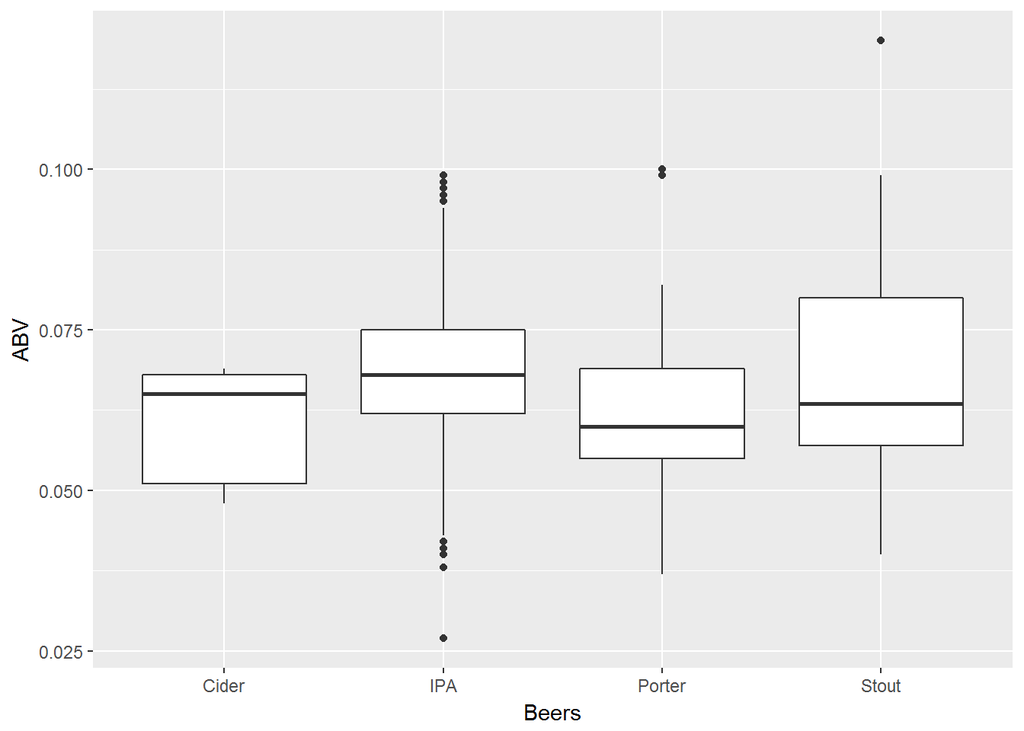

```r
ggplot(data = favs) +
  geom_boxplot(mapping = aes(favorite, abv)) +
  labs(x = 'Beers', y = 'ABV')
```

Next, we fit an ANOVA and see that the residuals appear to be normally distributed, as evidenced by the density and qqplot plots below.

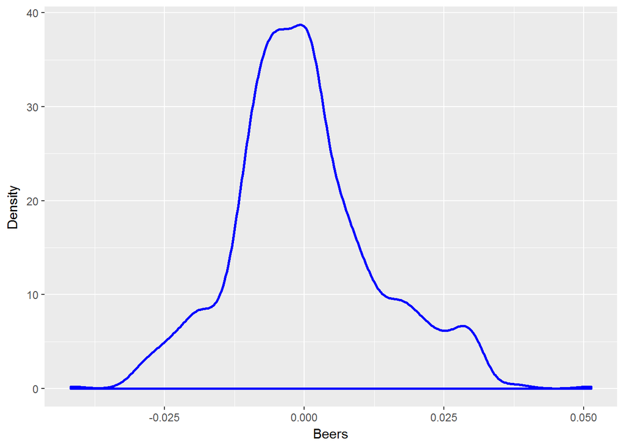

```r
anova_style <- aov(abv ~ favorite, data = favs)
anova_res <- tibble(res = resid(anova_style))

ggplot(data = anova_res) +
  geom_density(mapping = aes(res), lwd = 1, color = 'blue') +
  labs(x = 'Beers', y = 'Density')
```

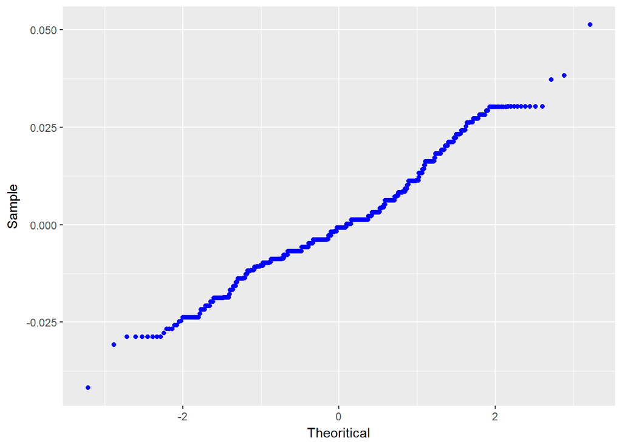

```r
ggplot(data = anova_res) +
  geom_qq(mapping = aes(sample = res), color = 'blue') +
  labs(x = 'Theoritical', y = 'Sample')
```

The ANOVA output below shows that there is indeed a *significant* difference in ABV content among the beer styles (with a p-value of <0.001). And in fact, there is a *significant* difference of almost 1% among all the beer types except Stouts vs. IPAs, and Porters vs. Ciders.

```r
summary(anova_style)
```

```
##              Df  Sum Sq  Mean Sq F value   Pr(>F)
## favorite      3 0.00518 0.001727   10.53 8.59e-07 ***
## Residuals   760 0.12463 0.000164
## ---
## Signif. codes:  0 '***' 0.001 '**' 0.01 '*' 0.05 '.' 0.1 ' ' 1
## 18 observations deleted due to missingness
```

```r
round(TukeyHSD(anova_style)$favorite, 3)
```

```
##                diff    lwr    upr p adj
## IPA-Cider     0.008  0.003  0.014 0.001
## Porter-Cider  0.001 -0.005  0.008 0.963
## Stout-Cider   0.008  0.002  0.015 0.005
## Porter-IPA   -0.007 -0.011 -0.003 0.000
## Stout-IPA     0.000 -0.004  0.004 1.000
## Stout-Porter  0.007  0.002  0.012 0.003
```

### America vs. England

One of the age old questions will finally be solved, which beer has more alcohol content (ABV), American or English style? We will tackle this question with bootstrapping the difference in medians.

The boxplot below shows that there may be a difference in medians between the two samples, but it’s hard to be sure.

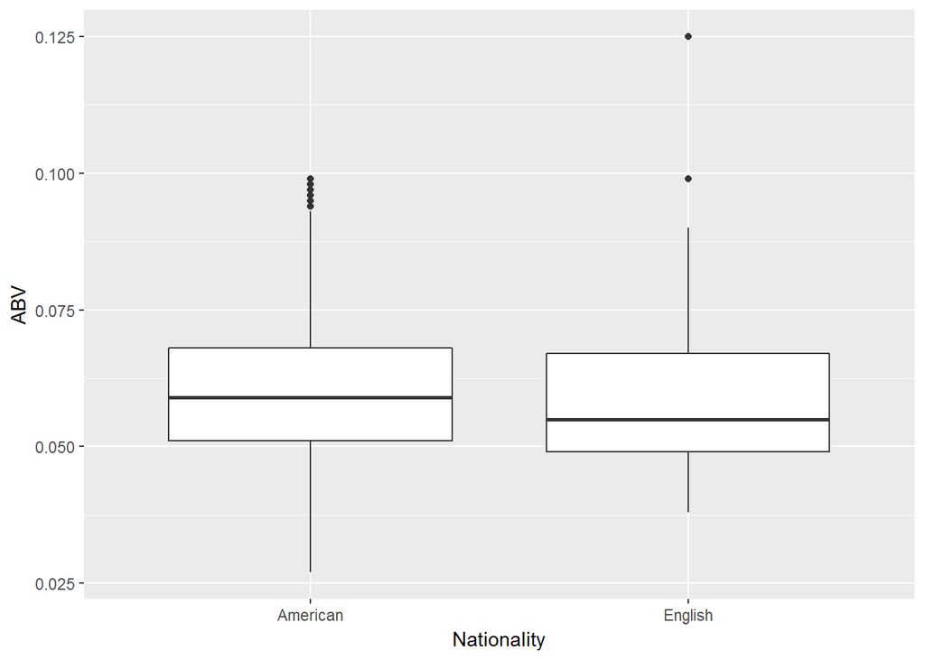

```r
nation <- beers %>%
  mutate(nationality = ifelse(str_detect(style, 'America'), 'American',
                              ifelse(str_detect(style, 'English'), 'English',
                                     'Other'))) %>%
  filter(nationality != 'Other')

ggplot(nation) +
  geom_boxplot(mapping = aes(x = nationality, y = abv)) +
  labs(x = 'Nationality', y = 'ABV')
```

So we’ll come up with a test statistic by using bootstrapped samples. The actual difference in medians between the two samples is 0.004; we’ll have a look to see how this compares to the 1000 bootstrapped samples.

```r
set.seed(10)
original_diff <- median(filter(nation, nationality == 'American')$abv, na.rm = T) -
                 median(filter(nation, nationality == 'English')$abv, na.rm = T)

nation_median <- nation %>%
  filter(!is.na(abv))

median_boot <- function(data, r = 1000){
  size <- nrow(data)
  med_values <- rep(0, r)
  new_abv <- tibble(abv = rep(0, size), nat = rep(0, size))

  for (i in 1:r){
    new_abv$abv <- sample_n(data, size = size, replace = T)$abv
    new_abv$nationality <- sample_n(data, size = size, replace = F)$nationality
    med_values[i] <- median(filter(new_abv, nationality == 'American')$abv) -                               median(filter(new_abv, nationality == 'English')$abv)
  }
  med_values
}

diff_values <- median_boot(nation_median, 1000)

paste("p-value:", sum(original_diff > diff_values) / length(diff_values))
```

```
## [1] "p-value: 0.946"
```

Here’s a visual of the simulated test statistic values, with our original difference in medians highlighted with a red vertical line.

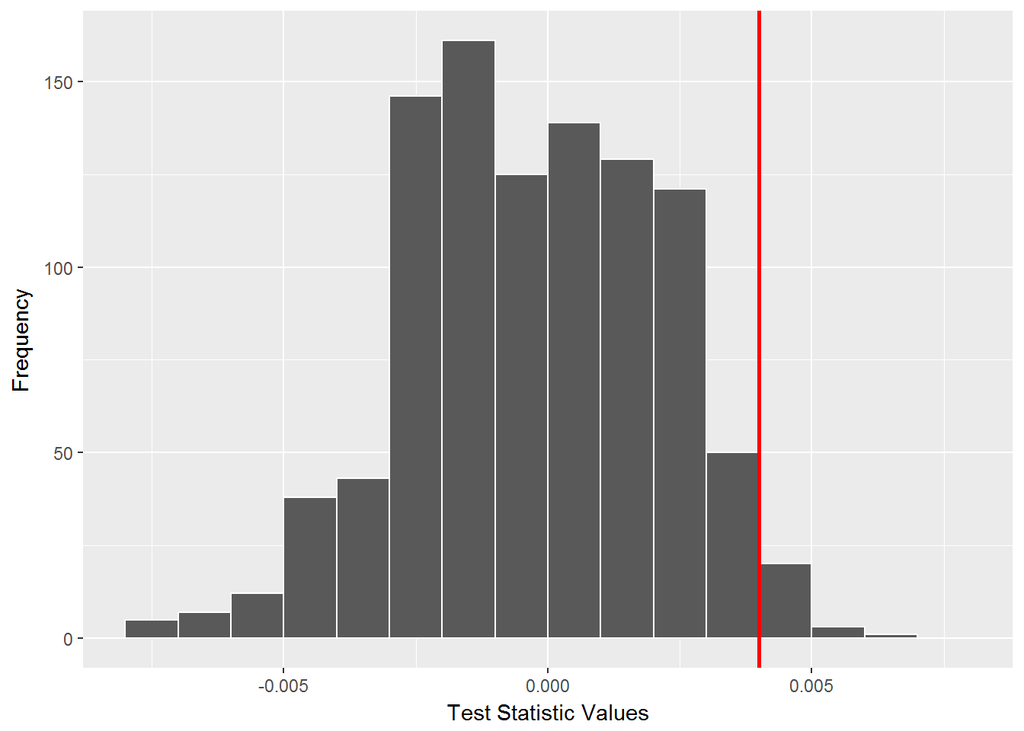

```r
ggplot(as_tibble(diff_values)) +
  geom_histogram(aes(x = value), breaks = seq(-.008, .008, .001), color = 'white') +
  geom_vline(xintercept = original_diff, color = 'red', lwd = 1) +
  labs(x = 'Test Statistic Values', y = 'Frequency')
```